# American Community Survey 2013-17 Project Report

Aayush Patel - 0672897

## **Data Summary**

In this project, I have used Population data from 2013-17 American Community Survey(ACS) which is a sample of the actual responses collected by the American Community Survey between 2013-2017, and split into population and household characteristics. This project, mainly focusses on features including but not limited to “Income”, “Class Of Worker”, “Different types of Difficulties faced by people in U.S” , “Level of Education”, “Insurance_from_private_companies”. In addition to different graphical and tabular summaries/analysis, this project also uses Supervised Machine Learning algorithms, Deep Learning - Artificial Neural Networks and Statistical Tests in order to predict or analyze following things:

- Support Vector Machine - Classification Algorithm is used to predict Income group into five different categories i.e “Very Low”, “Low”,“Average”,“Above average” and “High”
- Artificial Neural Network -ANN is used to find which features influences people to buy Insurance from a private company. This model can be useful to Insurance companies to find which group of people are likely to buy Insurance so that they can make their marketing and promotional strategies
- Statistical Test - Ansari test is used to test whether Men and Women in Computer Engineering field earns the same or not.

## **Methodology**

In order to perform analysis, this project has some key points to focus on how data has been accessed, manipulated, transformed and analyzed.

- Firstly, as this data is a micro data, I have used “PWGTP” variable which is a person weight in order to find total count of people per each observation. Eg. sum(PWGTP)
- As the Income had an adjustment factor for every year, a new column has been made called as “Income_with_ADJINC” = (“PINCP” * “ADJINC”) / 1000000 where PINCP is Income.
- In order to predict Income, SVM was used because it’s ability to perform well when there are large number of features and work with Multi-dimensional data.
- For faster processing speed, model training and some analysis were done on **M5.2xlarge- EC2 Instance from AWS** which costs around 25 USD for the whole project including storage and compute capacity
- For saving and loading data and ML models, this project uses readRDS() and saveRDS() functions. Hence majority of transformed and manipulated data were saved in form of .rds which save a lot of time while Knitting and performing analysis again.
- Other methdologies will be disscussed in the later sections of the project where actual analysis has been done!

## **Loading and Pre-processing Data**

Loading Data

```r
columns <- c("ST","REGION","PWGTP","CIT","COW","ADJINC","PINCP","RAC1P","DDRS","DEAR","DEYE","DOUT","AGEP","SEX", "FOD1P","SCHL")
read_file_a <-   fread("/home/ayush/Downloads/csv_pus/psam_pusa.csv",select=columns)
read_file_b <- fread("/home/ayush/Downloads/csv_pus/psam_pusb.csv",select=columns)
read_file_c <- fread("/home/ayush/Downloads/csv_pus/psam_pusc.csv",select=columns)
read_file_d <- fread("/home/ayush/Downloads/csv_pus/psam_pusd.csv",select=columns)
data_merged <- rbind(read_file_a,read_file_b,read_file_c,read_file_d)
data_for_analysis_without_removing_na <- tbl_df(data_merged)
```

Creating a new column which represnts State names.

```r
stateCode = "ST,State
1,Alabama/AL
2,Alaska/AK
4,Arizona/AZ
5,Arkansas/AR
6,California/CA
8,Colorado/CO
9,Connecticut/CT
10,Delaware/DE
11,DistrictofColumbia/DC
12,Florida/FL
13,Georgia/GA
15,Hawaii/HI
16,Idaho/ID
17,Illinois/IL
18,Indiana/IN
19,Iowa/IA
20,Kansas/KS
21,Kentucky/KY
22,Louisiana/LA
23,Maine/ME
24,Maryland/MD
25,Massachusetts/MA
26,Michigan/MI
27,Minnesota/MN
28,Mississippi/MS
29,Missouri/MO
30,Montana/MT
31,Nebraska/NE
32,Nevada/NV
33,NewHampshire/NH
34,NewJersey/NJ
35,NewMexico/NM
36,NewYork/NY
37,NorthCarolina/NC
38,NorthDakota/ND
39,Ohio/OH
40,Oklahoma/OK
41,Oregon/OR
42,Pennsylvania/PA
44,RhodeIsland/RI
45,SouthCarolina/SC
46,SouthDakota/SD
47,Tennessee/TN
48,Texas/TX
49,Utah/UT
50,Vermont/VT
51,Virginia/VA
53,Washington/WA
54,WestVirginia/WV
55,Wisconsin/WI
56,Wyoming/WY
72,PuertoRico/PR"

statecodes <- fread(stateCode)

data_for_analysis_without_removing_na <- left_join(data_for_analysis_without_removing_na,statecodes,by="ST")

# Remove NA data
data_for_analysis <- na.omit(data_for_analysis_without_removing_na)
data_for_analysis <- left_join(data_for_analysis,statecodes,by="ST")

# Adjusting Income with ADJINC year wise
data_for_analysis$Income_with_ADJINC <- as.integer(as.numeric(data_for_analysis$ADJINC) * as.numeric(data_for_analysis$PINCP) /1000000)

data_for_analysis_without_removing_na$Income_with_ADJINC <- as.integer(as.numeric(data_for_analysis_without_removing_na$ADJINC) * as.numeric(data_for_analysis_without_removing_na$PINCP) /1000000)

#Save data as RDS format
saveRDS(data_for_analysis,"data_for_analysis.rds")
saveRDS(data_for_analysis_without_removing_na,"data_for_analysis_without_removing_na.rds")
```

Read RDS to load data.

```r
library(DT)

data_for_analysis <- readRDS("data_for_analysis.rds")
data_for_analysis_without_removing_na <- readRDS("data_for_analysis_without_removing_na.rds")


#data_for_analysis <- do.call("cbind",data_for_analysis)

#data_for_analysis <- as.data.frame(data_for_analysis)

data_for_analysis$DDRS <- as.numeric(data_for_analysis$DDRS)
data_for_analysis$DEAR <- as.numeric(data_for_analysis$DEAR)
data_for_analysis$DEYE <- as.numeric(data_for_analysis$DEYE)
data_for_analysis$DOUT <- as.numeric(data_for_analysis$DOUT)
data_for_analysis$PWGTP <- as.numeric(data_for_analysis$PWGTP)

#DT::datatable(head(data_for_analysis,50))
#head(data_for_analysis,10)
#
# data_for_analysis$DDRS = factor(data_for_analysis$DDRS)
# data_for_analysis$DEAR = factor(data_for_analysis$DEAR)
# data_for_analysis$DEYE = factor(data_for_analysis$DEYE)
# data_for_analysis$DOUT = factor(data_for_analysis$DOUT)
```

## **Analysis of Region wide difficulty problems registered by people in U.S**

This section of project focusses on analyzing registered people facing difficulties across different states and regions in U.S. Analyzing the difficulties faced by people would help U.S government to provide specific services and improve their services to people.

Note: This section uses .tabset feature in order to create different Tabs for every Region in U.S

### **Northeast Region -1**

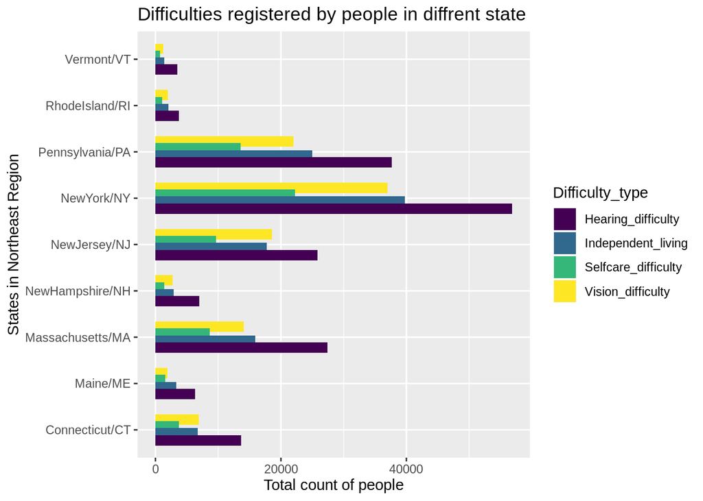

```r
# Find the total population per region

region_northeast <- data_for_analysis %>%
  filter(REGION==1) %>%
  group_by(State) %>%
  summarise(total_pop = sum(PWGTP),
            Selfcare_difficulty = sum(PWGTP[DDRS==1]),
            Hearing_difficulty = sum(PWGTP[DEAR==1]),
            Vision_difficulty = sum(PWGTP[DEYE==1]),
            Independent_living = sum(PWGTP[DOUT==1])
            )

region_northeast <- gather(region_northeast,Difficulty_type, Total, Selfcare_difficulty:Independent_living)
region_northeast$State <- factor(region_northeast$State)
region_northeast$Difficulty_type <- factor(region_northeast$Difficulty_type)

library(viridis)
ggplot(region_northeast, aes(State,Total,fill=Difficulty_type,label=Total))+geom_col(stat = "identity",position = position_dodge(0.6)) +coord_flip() + scale_fill_viridis(discrete=TRUE,option = "D") + labs (
  title = "Difficulties registered by people in diffrent state",
  y= "Total count of people",
  x="States in Northeast Region"
)
```

### **Midwest -2**

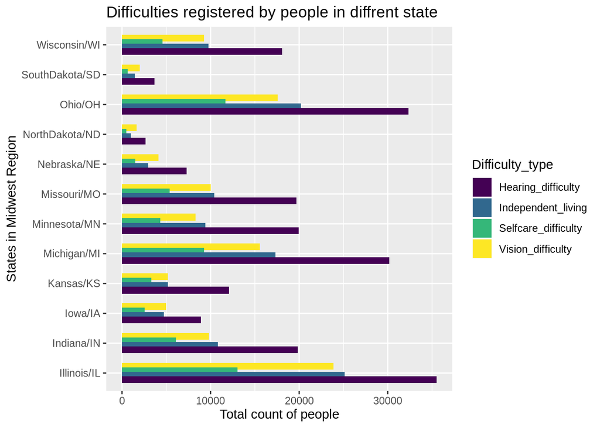

```r
# Find the total population per region

region_midwest <- data_for_analysis %>%
  filter(REGION==2) %>%
  group_by(State) %>%
  summarise(total_pop = sum(PWGTP),
            Selfcare_difficulty = sum(PWGTP[DDRS==1]),
            Hearing_difficulty = sum(PWGTP[DEAR==1]),
            Vision_difficulty = sum(PWGTP[DEYE==1]),
            Independent_living = sum(PWGTP[DOUT==1])
            )

region_midwest <- gather(region_midwest,Difficulty_type, Total, Selfcare_difficulty:Independent_living)
region_midwest$State <- factor(region_midwest$State)
region_midwest$Difficulty_type <- factor(region_midwest$Difficulty_type)

ggplot(region_midwest, aes(State,Total,fill=Difficulty_type,label=Total))+geom_bar(stat = "identity",position =position_dodge(0.6)) +coord_flip() + scale_fill_viridis(discrete=TRUE,option = "D") + labs (
  title = "Difficulties registered by people in diffrent state",
  y= "Total count of people",
  x="States in Midwest Region"
)
```

### **South -3**

[figure not shown]

```r
# Find the total population per region

region_south <- data_for_analysis %>%
  filter(REGION==3) %>%
  group_by(State) %>%
  summarise(total_pop = sum(PWGTP),
            Selfcare_difficulty = sum(PWGTP[DDRS==1]),
            Hearing_difficulty = sum(PWGTP[DEAR==1]),
            Vision_difficulty = sum(PWGTP[DEYE==1]),
            Independent_living = sum(PWGTP[DOUT==1])
            )

region_south <- gather(region_south,Difficulty_type, Total, Selfcare_difficulty:Independent_living)
region_south$State <- factor(region_south$State)
region_south$Difficulty_type <- factor(region_south$Difficulty_type)

ggplot(region_south, aes(State,Total/1e3,fill=Difficulty_type,label=Total))+geom_bar(stat = "identity",position =position_dodge(0.6)) +coord_flip() + scale_fill_viridis(discrete=TRUE,option = "D") + labs (
  title = "Difficulties registered by people in diffrent state",
  y= "Total count of people IN Hundred's",
  x="States in South Region "
)
```

### **West -4**

[figure not shown]

```r
# Find the total population per region

region_west <- data_for_analysis %>%
  filter(REGION==4) %>%
  group_by(State) %>%
  summarise(total_pop = sum(PWGTP),
            Selfcare_difficulty = sum(PWGTP[DDRS==1]),
            Hearing_difficulty = sum(PWGTP[DEAR==1]),
            Vision_difficulty = sum(PWGTP[DEYE==1]),
            Independent_living = sum(PWGTP[DOUT==1])
            )

region_west <- gather(region_west,Difficulty_type, Total, Selfcare_difficulty:Independent_living)
region_west$State <- factor(region_west$State)
region_west$Difficulty_type <- factor(region_west$Difficulty_type)

ggplot(region_west, aes(State,Total/1e3,fill=Difficulty_type,label=Total/1e3))+geom_bar(stat = "identity",position = position_dodge(0.6)) +coord_flip() + scale_fill_viridis(discrete=TRUE,option = "D") + labs (
  title = "Difficulties registered by people in diffrent state",
  y= "Total count of people IN Hundred's",
  x="States in West Region"
)
```

**Interpretation and Summary of above Analysis:**

- It can be easily seen that “Hearing_Difficulity” is the most common difficulty accross all states in U.s
- California has the highest no of people having hearing problems. Note: This also might be because of higher population in Califoria than some other States.
- South and West Regions(only California) have more no of people having difficulties than Midwest and Northeast Region.
- Very few registered people had “Self_living difficulty” in comparision with other difficulties type.

## **Average income for different class of workers from 2013-17**

This section focusses on on how average income for different class of workers changed from 2013 to 2017. I asssumed that there would be change in income from 2013 to 2017.

Note: As there was no column in dataset which would tell the year of that record, Hence, I used ADJINC variable which is an adjustment variable for diffrent years.

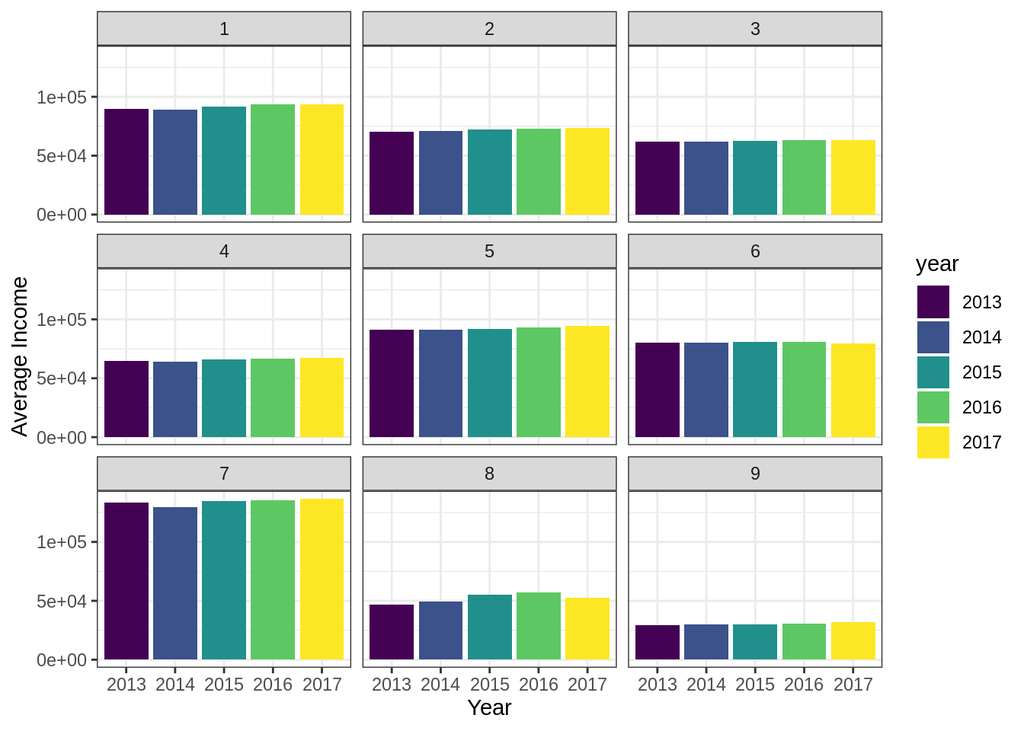

```r
# Using ADJINC to create a new column "year"
data_for_analysis <- data_for_analysis %>%
  mutate( year = case_when(
    ADJINC==1061971 ~ "2013",
    ADJINC==1045195 ~ "2014",
    ADJINC==1035988 ~ "2015",
    ADJINC==1029257 ~ "2016",
    ADJINC==1011189 ~ "2017"
    ))

#FIltering out negative and very low income.
data_for_analysis <- data_for_analysis %>%
  filter(Income_with_ADJINC>5000)

yearly_avg_income_by_cow <- data_for_analysis %>%
  group_by(year,COW) %>%
  summarise(mean_income = mean(Income_with_ADJINC)) %>%
  arrange(year)

yearly_avg_income_by_cow <- yearly_avg_income_by_cow %>%
  mutate( COW_Desc = case_when(
    COW==1 ~ "Employee of a private for-profit company or business",
    COW==2 ~ "Employee of a private not-for-profit, tax-exempt, or
.charitable organization",
    COW==3 ~ "Local government employee",
    COW==4 ~ "State government employee",
    COW==5 ~ "Federal government employee",
    COW==6 ~ "Self-employed in own not incorporated business",
    COW==7 ~ "Self-employed in own incorporated business",
    COW==8 ~ "Working without pay in family business or farm",
    COW==9 ~ "Unemployed and last worked 5 years ago"

    ))

library(ggplot2)

ggplot(yearly_avg_income_by_cow, aes(x=year, y=mean_income, fill=year))+geom_bar(stat = "identity")+ facet_wrap(~factor(COW))+ theme(
   strip.background = element_rect(
     color="white", fill="#A7C8E9", size=1.5, linetype="solid"
     ))+ scale_fill_viridis(discrete=TRUE,option = "D")+ labs(
       x="Year",
       y="Average Income"
     )+theme_bw()
```

From the above graph for different class of worker,we can conclude following things.

- There is not much diffrence in salaries reported for all different class of workers from 2013 to 2017
- Class of Worker - 7 which is “Self-employed in own incorporated business” earned the most among all other COW’s.
- COW-8 and COW-9 earned the lowest which are “Working withot pay in family business” and “Unemployed or did not work from past 5 years”

## **Income analysis of Self-employed in own incorporated business per State**

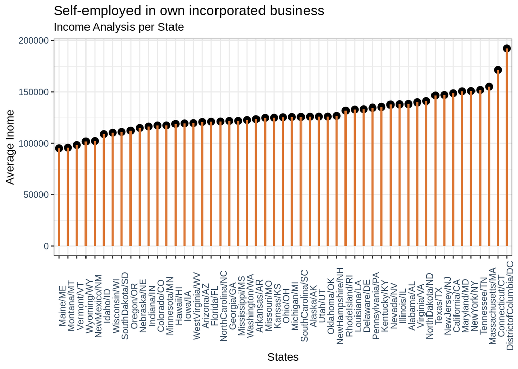

```r
Cow_7_Income_by_state <- data_for_analysis %>%
  filter(COW==7) %>%
  group_by(State) %>%
  summarise(
    mean_inc = mean(Income_with_ADJINC)
  )


ggplot(Cow_7_Income_by_state, aes(x=fct_reorder(State,mean_inc), y=mean_inc)) +
  geom_point(size=3) +
  geom_segment(aes(x=State,
                   xend=State,
                   y=0,
                   yend=mean_inc),size=1, color="#DC7633") +
  labs(title="Self-employed in own incorporated business",
       subtitle="Income Analysis per State",
       x="States",
       y="Average Inome"
       ) +
  theme_bw()+
  theme(axis.text.x = element_text(angle=90, vjust=1.0,color="#34495E"),
                                   axis.text.y  = element_text(color="#34495E"))
```

### **Sum of people having income greater than mean income per state.**

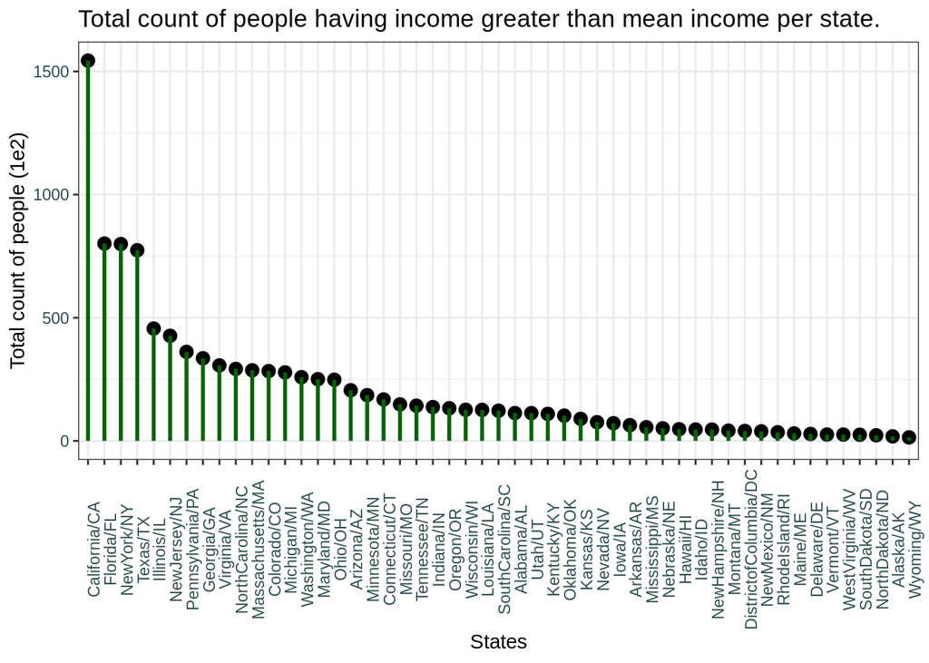

```r
Cow_7_people_greater_than_mean_income <- data_for_analysis %>%
  filter(COW==7) %>%
  group_by(State) %>%
  summarise(
    mean_income <-mean(Income_with_ADJINC),
    count_people = sum(PWGTP[Income_with_ADJINC>mean_income])
  ) %>%
  arrange(desc(count_people))


ggplot(Cow_7_people_greater_than_mean_income, aes(x=fct_reorder(State,count_people/1e2,.desc=TRUE), y=count_people/1e2)) +
  geom_point(size=3) +
  geom_segment(aes(x=State,
                   xend=State,
                   y=0,
                   yend=count_people/1e2),size=1, color="darkgreen") +
  labs(title="Total count of people having income greater than mean income per state.",

       y="Total count of people (1e2)",
        x= "States"
       ) +
  theme_bw()+
  theme(axis.text.x = element_text(angle=90, vjust=1.0,color="darkslategrey"),
                                   axis.text.y  = element_text(color="darkslategrey"))
```

## **How does Income vary with AGE?**

With this analysis and graph, we can see that Income increases continously as the Age increases - till 55. After Age=55 it tends to decrease again.

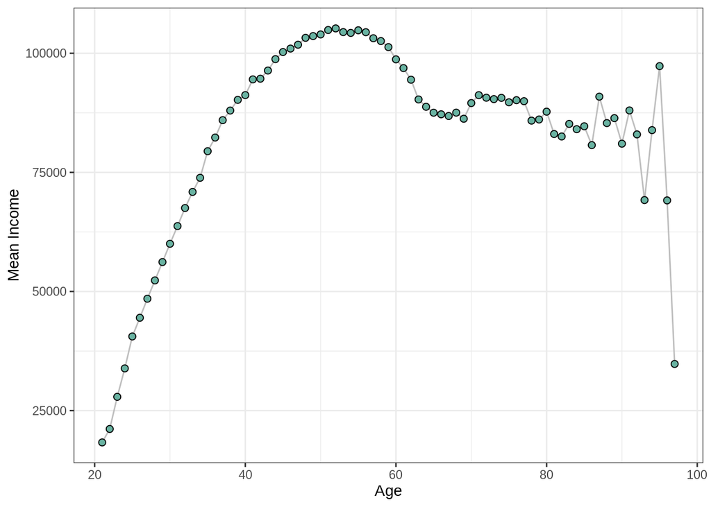

```r
#ONly considered people with AGE>20.

cow7_age_distribuition <- data_for_analysis %>%
  filter(AGEP>20) %>%
  group_by(AGEP) %>%
  summarize(avg_income_by_age= mean(Income_with_ADJINC)) %>%
  select(AGEP,avg_income_by_age) %>%
  arrange(AGEP)

 ggplot(cow7_age_distribuition, aes(x=AGEP, y=avg_income_by_age)) +
    geom_line( color="grey") +
    geom_point(shape=21, color="black", fill="#69b3a2", size=2)+ theme_bw()+ labs(
      x="Age",
      y="Mean Income"
    )
```

## **Analysis of Engineering Fields Income affected by level of education.**

As, I am highly interested in engineering field, This section of the project focusses on analysing Income variation for different fields of engineering with different level of education. Eg. Bachelor’s, Master’s, Doctorate and Professional Degree After Bachelors.

Note: In this analysis, I have compared Incomes in this manner.

- Master’s to Bachelor’s - Percentage of Income increased or decreased for a specific field when Master’s is done.
- Professional Degree to Master’s - Percentage of Income increased or decreased
- Doctorate to Professional Degree - Percentage of Income increased or decreased

```r
#Filtering only engineering Fields
engineering_income <- data_for_analysis %>%
  filter(FOD1P==2401 | FOD1P==2402 | FOD1P==2403| FOD1P==2404| FOD1P==2405| FOD1P==2406|  FOD1P==2407| FOD1P==2408| FOD1P==2410 | FOD1P==2418 , Income_with_ADJINC>10000) %>%
  group_by(SCHL,FOD1P) %>%
  summarise( mean_inc = mean(Income_with_ADJINC))


engineering_income$FOD1P <- factor(engineering_income$FOD1P)
levels(engineering_income$FOD1P)[levels(engineering_income$FOD1P)==2401] <- "Aerospace"
levels(engineering_income$FOD1P)[levels(engineering_income$FOD1P)==2402] <- "Biological"
levels(engineering_income$FOD1P)[levels(engineering_income$FOD1P)==2403] <- "Architectural"
levels(engineering_income$FOD1P)[levels(engineering_income$FOD1P)==2404] <- "Biomedical"
levels(engineering_income$FOD1P)[levels(engineering_income$FOD1P)==2405] <- "Chemical"
levels(engineering_income$FOD1P)[levels(engineering_income$FOD1P)==2406] <- "Civil"
levels(engineering_income$FOD1P)[levels(engineering_income$FOD1P)==2407] <- "Computer"
levels(engineering_income$FOD1P)[levels(engineering_income$FOD1P)==2408] <- "Electical"
levels(engineering_income$FOD1P)[levels(engineering_income$FOD1P)==2410] <- "Environmental"
levels(engineering_income$FOD1P)[levels(engineering_income$FOD1P)==2418] <- "Nuclear Eng."

engineering_income <- engineering_income %>%
  spread(SCHL,mean_inc)

names(engineering_income)[1] <-"Engineering Branch"
names(engineering_income)[3] <-"Masters"
names(engineering_income)[2] <-"Bachelors"
names(engineering_income)[4] <- "ProfessionalDegree"
names(engineering_income)[5] <- "Doctorate"


display_data <- engineering_income
display_data$Bachelors <- as.integer(display_data$Bachelors)
display_data$Masters <- as.integer(display_data$Masters)
display_data$ProfessionalDegree <- as.integer(display_data$ProfessionalDegree)
display_data$Doctorate <- as.integer(display_data$Doctorate)


display_data$Masters= display_data$Masters/display_data$Bachelors
display_data$ProfessionalDegree= display_data$ProfessionalDegree/display_data$Bachelors
display_data$Doctorate= display_data$Doctorate/display_data$Bachelors


improvement_formatter <- formatter("span", style = x ~ style(font.weight = "bold",
                                                     color = ifelse(x > 0, customGreen, ifelse(x < 0, customRed, "black"))),
                                   x ~ icontext(ifelse(x == max(x), "thumbs-up", ""), x)
)


formattable(display_data,
             list(

              `Engineering Branch` = formatter("span",
                        style = ~ style(color = "blue",font.weight = "bold"),
                        x~icontext(ifelse(x=="Architectural" | x=="Computer","star",""),x)),
              `Masters`= formatter("span", style = ~ style(color = ifelse(`Masters` <`Bachelors`, "green", "red")),~ icontext(ifelse(`Masters` <`Bachelors`,"arrow-up", "arrow-down"), `Masters`)),
               ProfessionalDegree= formatter("span", style = ~ style(color = ifelse(ProfessionalDegree > `Masters`, "green", "red")),~ icontext(ifelse(ProfessionalDegree >`Masters`,"arrow-up", "arrow-down"), ProfessionalDegree)),
              `Doctorate`= formatter("span", style = ~ style(color = ifelse(`Doctorate` >ProfessionalDegree, "darkgreen", "red")),~ icontext(ifelse(`Doctorate` > ProfessionalDegree,"arrow-up", "arrow-down"), `Doctorate`))
              ))
```

| Engineering Branch | Bachelors | Masters | ProfessionalDegree | Doctorate |
| --- | --- | --- | --- | --- |
| Aerospace | 102978 | 1.31652391773 | 1.76073530268601 | 1.46980908543572 |
| Biological | 84204 | 1.16619162985131 | 2.05955774072491 | 1.32744287682295 |
| Architectural | 99951 | 1.01341657412132 | 1.22420986283279 | 1.47674360436614 |
| Biomedical | 75992 | 1.33183756184862 | 2.67663701442257 | 1.55784819454679 |
| Chemical | 109466 | 1.27237681106462 | 1.81242577604005 | 1.33232236493523 |
| Civil | 101069 | 1.23401834390367 | 1.40721685185368 | 1.33181291988641 |
| Computer | 101954 | 1.23963748357102 | 1.33993761892618 | 1.44064970476882 |
| Electical | 107808 | 1.27019330661917 | 1.72718165627783 | 1.49103962600178 |
| Environmental | 78699 | 1.3358619550439 | 1.53848206457515 | 1.34207550286535 |
| Nuclear Eng. | 114685 | 1.20367092470681 | 1.66659981688974 | 1.38412172472424 |

Summary or Interpretation of the above tabular summary:

- Only two field of engineering had advantage of doing Phd 1. Architectural 2. Computer.(Indicated by STAR in table) We can see this from an upward arrow which shows there has been an increase in Income percentage from doing Professional Degree.
- According to survey data, we can say that pursuing Master’s and Professional Degree in any field of engineering is always helpful in terms of Income.